# optimalFlow: optimal-transport approach to Flow Cytometry analysis

Hristo Inouzhe

Universidad de Valladolid, Spain

hristo.inouzhe@gmail.com

17 septiembre, 2019

# 1 Introduction

*optimalFlow* is a package dedicated to applying optimal-transport techniques to supervised flow cytometry gating based on the results in del Barrio et al. (2019).

We provide novel methods for grouping (clustering) gated cytometries. By clustering a set of cytometries we are producing groups (clusters) of cytometries that have lower variability than the whole collection. This in turn allows to improve greatly the performance of any supervised learning procedure. Once we have a partition (clustering) of a collection of cytometries, we provide several methods for obtaining an artificial cytometry (prototype, template) that represents in some optimal way the cytometries in each respective group. These prototypes can be used, among other things, for matching populations between different cytometries. Even more, a procedure able to group similar cytometries could help to detect individuals with a common particular condition, for instance some kind of disease.

*optimalFlowTemplates* is our procedure for clustering cytometries and obtaining templates. It is based on recent developments in the field of optimal transport such as a *similarity distance* between clusterings and a *barycenter* (Frechet mean) and *k-barycenters* of probability distributions.

We introduce *optimalFlowClassification*, a supervised classification tool for the case when a database of gated cytometries is available. The procedure uses the prototypes obtained by *optimalFlowTemplates* on the database. These are used to initialize *tclust*, a robust extension of k-means that allows for non-spherical shapes, for gating a new cytometry (see Garcia-Escudero et al. (2008)). By using a similarity distance between the best clustering obtained by *tclust* and the artificial cytometries provided by *optimalFlowTemplates* we can assign the new cytometry to the most similar template (and the respective group of cytometries). We provide several options of how to assign cell types to the new cytometry using the most relevant information, represented by the assigned template and the respective cluster of cytometries.

# 2 Installation

Installation procedure:

```r
if (!requireNamespace("BiocManager", quietly = TRUE))
    install.packages("BiocManager")

BiocManager::install("optimalFLow")
```

# 3 optimalFlowTemplates

```r
library(optimalFlowData)
library(optimalFlow)
library(ellipse)
```

We start by providing a database of gated cytoimetries. In this case we have 15 cytometries with 4 cell types each.

```r
database = list(
  Cytometry2[which(Cytometry2$`Population ID (name)` %in% c("Monocytes", "CD4+CD8-", "Mature SIg Kappa", "TCRgd-")),],
  Cytometry3[which(Cytometry3$`Population ID (name)` %in% c("Monocytes", "CD4+CD8-", "Mature SIg Kappa", "TCRgd-")),],
  Cytometry4[which(Cytometry4$`Population ID (name)` %in% c("Monocytes", "CD4+CD8-", "Mature SIg Kappa", "TCRgd-")),],
  Cytometry5[which(Cytometry5$`Population ID (name)` %in% c("Monocytes", "CD4+CD8-", "Mature SIg Kappa", "TCRgd-")),],
  Cytometry7[which(Cytometry7$`Population ID (name)` %in% c("Monocytes", "CD4+CD8-", "Mature SIg Kappa", "TCRgd-")),],
  Cytometry8[which(Cytometry8$`Population ID (name)` %in% c("Monocytes", "CD4+CD8-", "Mature SIg Kappa", "TCRgd-")),],
  Cytometry9[which(Cytometry9$`Population ID (name)` %in% c("Monocytes", "CD4+CD8-", "Mature SIg Kappa", "TCRgd-")),],
  Cytometry12[which(Cytometry12$`Population ID (name)` %in% c("Monocytes", "CD4+CD8-", "Mature SIg Kappa", "TCRgd-")),],
  Cytometry13[which(Cytometry13$`Population ID (name)` %in% c("Monocytes", "CD4+CD8-", "Mature SIg Kappa", "TCRgd-")),],
  Cytometry14[which(Cytometry14$`Population ID (name)` %in% c("Monocytes", "CD4+CD8-", "Mature SIg Kappa", "TCRgd-")),],
  Cytometry15[which(Cytometry15$`Population ID (name)` %in% c("Monocytes", "CD4+CD8-", "Mature SIg Kappa", "TCRgd-")),],
  Cytometry16[which(Cytometry16$`Population ID (name)` %in% c("Monocytes", "CD4+CD8-", "Mature SIg Kappa", "TCRgd-")),],
  Cytometry17[which(Cytometry17$`Population ID (name)` %in% c("Monocytes", "CD4+CD8-", "Mature SIg Kappa", "TCRgd-")),],
  Cytometry19[which(Cytometry19$`Population ID (name)` %in% c("Monocytes", "CD4+CD8-", "Mature SIg Kappa", "TCRgd-")),],
  Cytometry21[which(Cytometry21$`Population ID (name)` %in% c("Monocytes", "CD4+CD8-", "Mature SIg Kappa", "TCRgd-")),]
  )
```

Then we apply optimal flow templates to obtain a clustering of the database and a template cytometry of each group. In this case we are looking for 5 distinct groups of cytometries.

```r
templates.optimalFlow =
  optimalFlowTemplates(
    database = database, templates.number = 5, cl.paral = 1
    )
```

```
## [1] "step 1: 1.74538350105286 secs"
## [1] "step 2: 1.28006720542908 secs"
## [1] "Execution time: 3.02599048614502 secs"
```

A two dimensional representation of the database, where we know every cell type, and consider every cytometry as a mixture of multivariate Gaussian ditributions is presented.

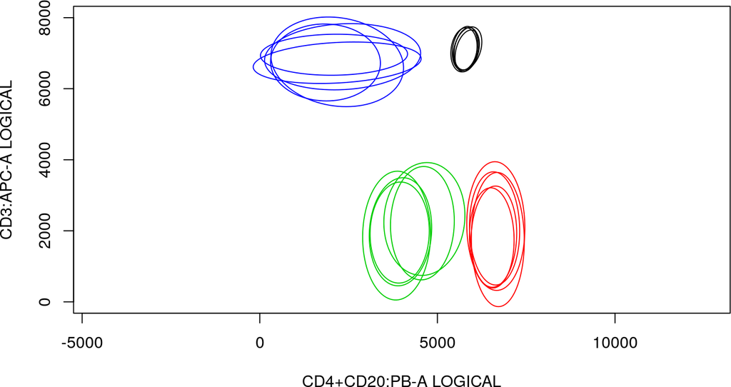

```r
plot(
  ellipse(
    templates.optimalFlow$database.elliptical[[3]][[1]]$cov[c(4,3),][,c(4,3)],
    centre = templates.optimalFlow$database.elliptical[[3]][[1]]$mean[c(4,3)]
    ),
  xlim = c(0,8000), ylim =c(0,8000), col = 1, type = "l",
  xlab = names(Cytometry1)[4], ylab = names(Cytometry1)[3], asp = 1
  )
for (j in 2:4){
  lines(
    ellipse(
      templates.optimalFlow$database.elliptical[[3]][[j]]$cov[c(4,3),][,c(4,3)],
      centre = templates.optimalFlow$database.elliptical[[3]][[j]]$mean[c(4,3)]
      ),
    col = j
    )
}

for (i in c(4:6,12)){
  for (j in 1:4){
    lines(
      ellipse(
        templates.optimalFlow$database.elliptical[[i]][[j]]$cov[c(4,3),][,c(4,3)],
        centre = templates.optimalFlow$database.elliptical[[i]][[j]]$mean[c(4,3)]
        ),
      col = j
      )
  }
}
```

A three dimensional plot of the same case is provided as a static image.

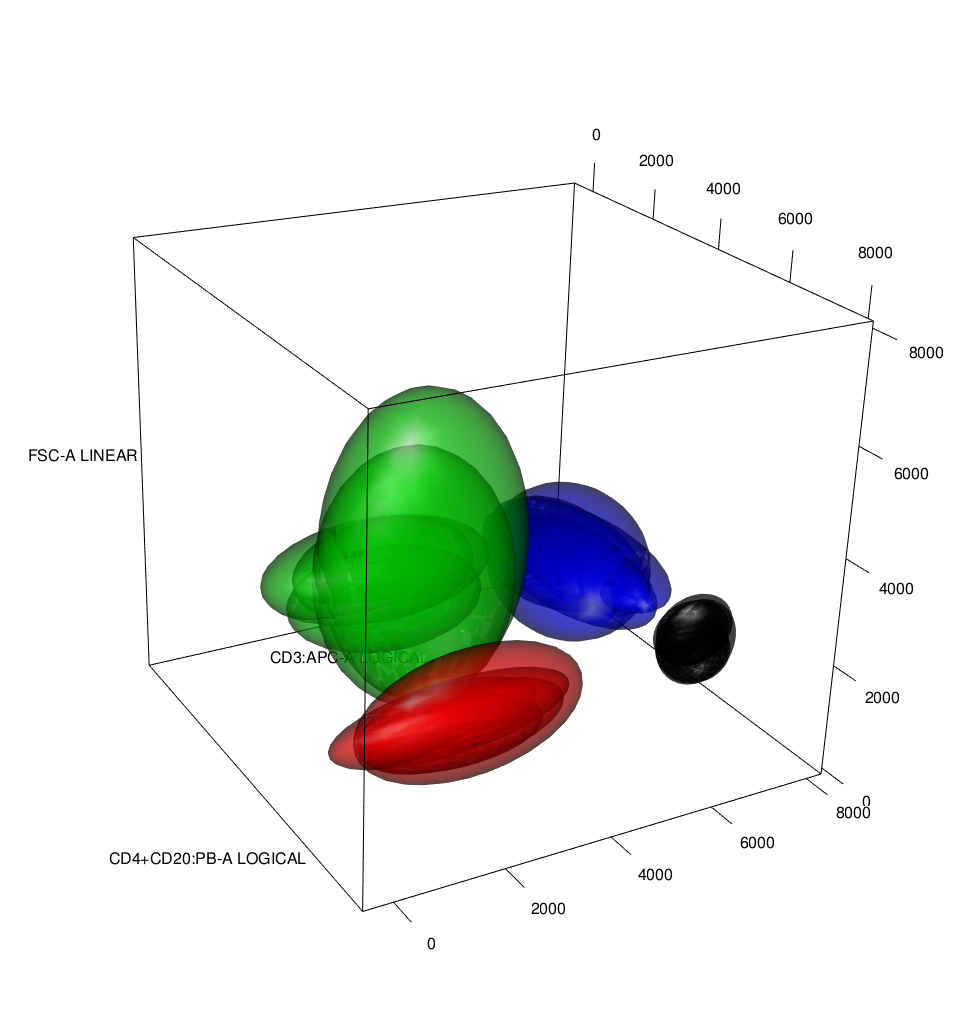

Figure 1: pooling database

The 2d plot of a consensus cytometry, a template, of one of the groups is the following.

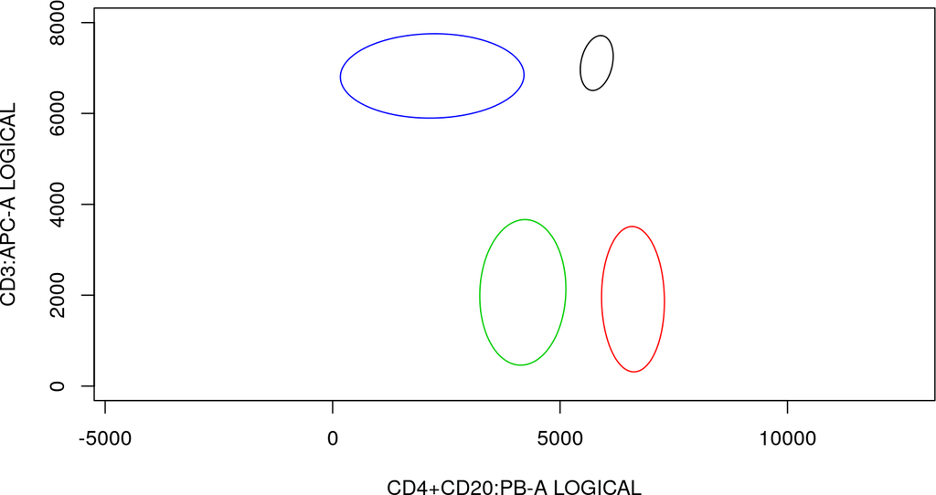

```r
plot(
  ellipse(
    templates.optimalFlow$templates[[3]][[1]]$cov[c(4,3),][,c(4,3)],
    centre = templates.optimalFlow$templates[[3]][[1]]$mean[c(4,3)]
    ),
  xlim = c(0,8000), ylim =c(0,8000), col = 1, type = "l",
  xlab = names(Cytometry1)[4], ylab = names(Cytometry1)[3], asp = 1
  )
for (j in 2:4){
  lines(
    ellipse(
      templates.optimalFlow$templates[[3]][[j]]$cov[c(4,3),][,c(4,3)],
      centre = templates.optimalFlow$templates[[3]][[j]]$mean[c(4,3)]
      ),
    col = j
    )
}
```

A three dimensional plot as a static image follows.

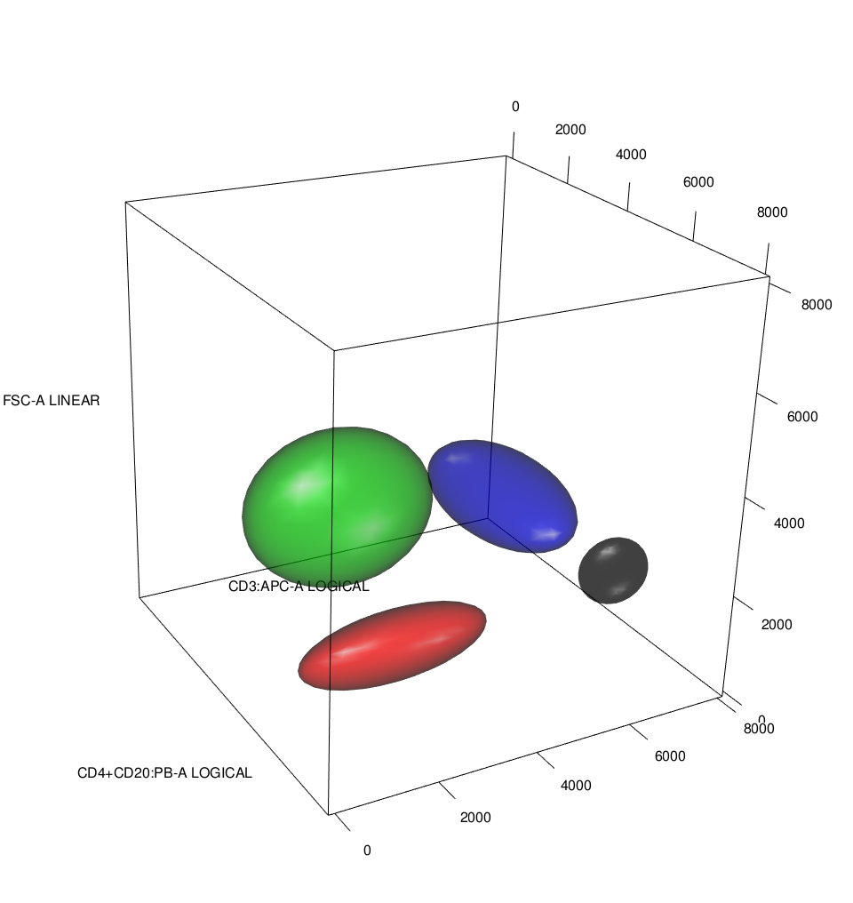

It is clear that the prototype cytometry represents well the geometric information of the respective group of cytometries.

However, sometimes gatings of cytometries are available but without the identification of each cell type. In that case a 2d representation of a group of cytometries would be the following.

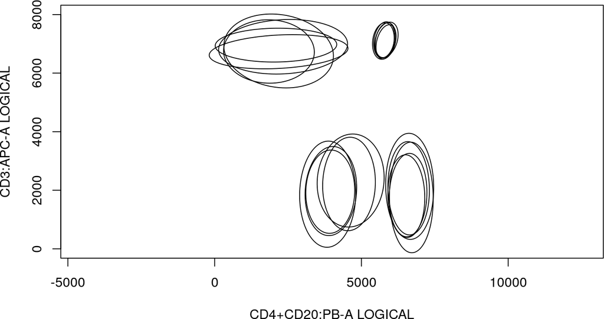

```r
plot(
  ellipse(
    templates.optimalFlow$database.elliptical[[3]][[1]]$cov[c(4,3),][,c(4,3)],
    centre = templates.optimalFlow$database.elliptical[[3]][[1]]$mean[c(4,3)]
    ),
  xlim = c(0,8000), ylim =c(0,8000), col = 1, type = "l",
  xlab = names(Cytometry1)[4], ylab = names(Cytometry1)[3], asp = 1
  )
for (j in 2:4){
  lines(
    ellipse(
      templates.optimalFlow$database.elliptical[[3]][[j]]$cov[c(4,3),][,c(4,3)],
      centre = templates.optimalFlow$database.elliptical[[3]][[j]]$mean[c(4,3)]
      ),
    col = 1
    )
}

for (i in c(4:6,12)){
  for (j in 1:4){
    lines(
      ellipse(
        templates.optimalFlow$database.elliptical[[i]][[j]]$cov[c(4,3),][,c(4,3)],
        centre = templates.optimalFlow$database.elliptical[[i]][[j]]$mean[c(4,3)]
        ),
      col = 1
      )
  }
}
```

With the respective 3d static image.

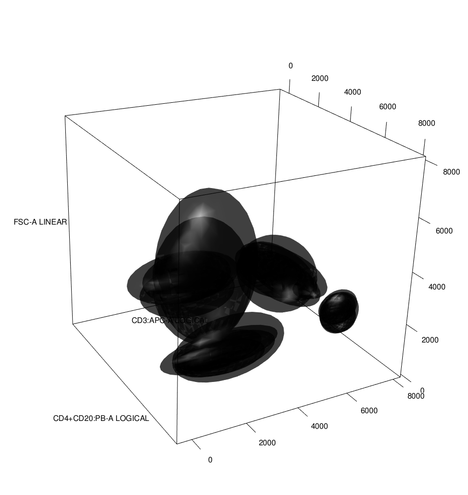

Figure 2: normal database

In this situation, it is advisable to use some unsupervised procedure to obtain the consensus element (the prototype cytometry). This can be achieved using *otpimalFlowTemplates* as follows.

```r
templates.optimalFlow.barycenter =
  optimalFlowTemplates(
    database = database, templates.number = 5, consensus.method = "k-barycenter",
    barycenters.number = 4, bar.repetitions = 10, alpha.bar = 0.05, cl.paral = 1
    )
```

```
## [1] "step 1: 1.72349047660828 secs"
## [1] "step 2: 30.1329007148743 secs"
## [1] "Execution time: 31.8565847873688 secs"
```

```r
templates.optimalFlow.hdbscan =
  optimalFlowTemplates(
    database = database, templates.number = 5, consensus.method = "hierarchical",
    cl.paral = 1
    )
```

```
## [1] "step 1: 1.70680046081543 secs"
## [1] "step 2: 5.51728487014771 secs"
## [1] "Execution time: 7.22421908378601 secs"
```

A 2d plot of a prototype cytometry is provided, where colors represent different groups (but not a certain cell type).

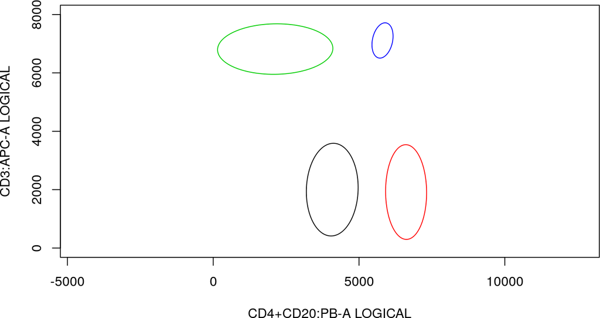

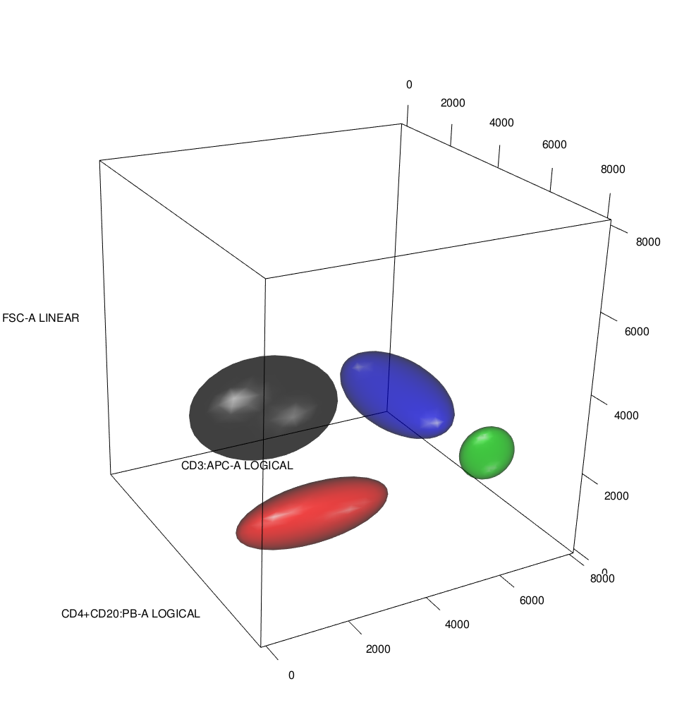

```r
plot(
  ellipse(
    templates.optimalFlow.barycenter$templates[[3]][[1]]$cov[c(4,3),][,c(4,3)],
    centre = templates.optimalFlow.barycenter$templates[[3]][[1]]$mean[c(4,3)]
    ),
  xlim = c(0,8000), ylim =c(0,8000), col = 1, type = "l",
  xlab = names(Cytometry1)[4], ylab = names(Cytometry1)[3], asp = 1
  )
for (j in 2:4){
  lines(
    ellipse(
      templates.optimalFlow.barycenter$templates[[3]][[j]]$cov[c(4,3),][,c(4,3)],
      centre = templates.optimalFlow.barycenter$templates[[3]][[j]]$mean[c(4,3)]
      ),
    col = j
    )
}
```

We notice that when using consensus.method = “hierarchical” we do not need to specify the number of clusters for the prototype cytometry. In that fashion we obtain the following consensus element.

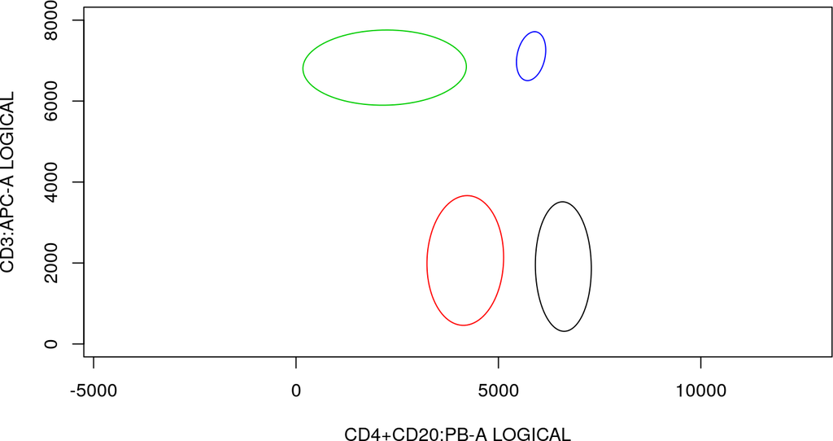

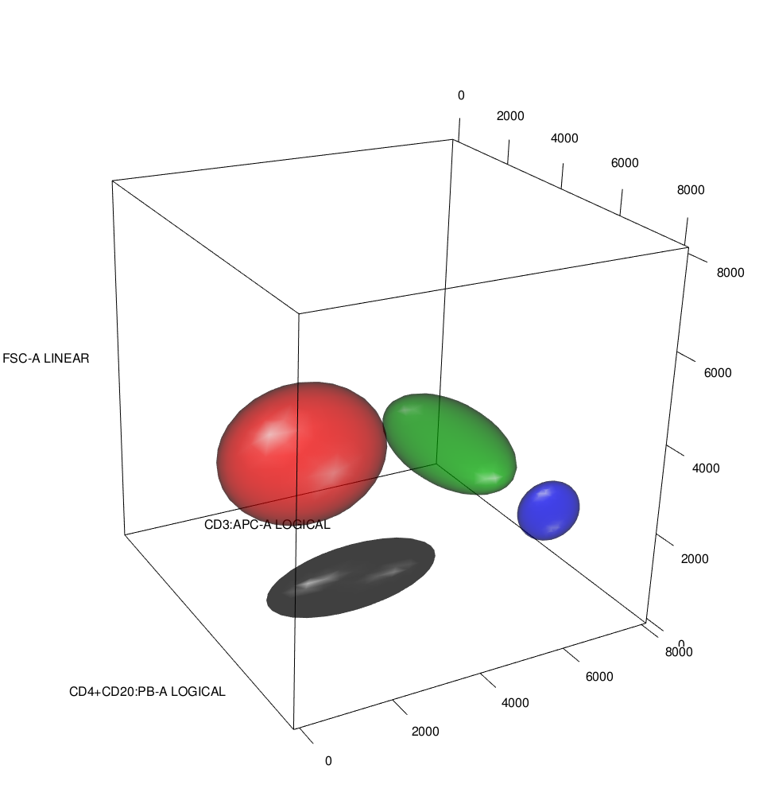

```r
plot(
  ellipse(
    templates.optimalFlow.hdbscan$templates[[3]][[1]]$cov[c(4,3),][,c(4,3)],
    centre = templates.optimalFlow.hdbscan$templates[[3]][[1]]$mean[c(4,3)]
    ),
  xlim = c(0,8000), ylim =c(0,8000), col = 1, type = "l",
  xlab = names(Cytometry1)[4], ylab = names(Cytometry1)[3], asp = 1
  )
for (j in 2:4){
  lines(
    ellipse(
      templates.optimalFlow.hdbscan$templates[[3]][[j]]$cov[c(4,3),][,c(4,3)],
      centre = templates.optimalFlow.hdbscan$templates[[3]][[j]]$mean[c(4,3)]
      ),
    col = j
    )
}
```

A totally unsupervised way of obtaining groups and templates is given next.

```r
templates.optimalFlow.unsup =
  optimalFlowTemplates(
    database = database, hclust.method = "hdbscan", cl.paral = 1, consensus.method = "hierarchical"
    )
```

```
## [1] "step 1: 1.72313976287842 secs"
## [1] "step 2: 6.02990889549255 secs"
## [1] "Execution time: 7.75318431854248 secs"
```

```r
print(templates.optimalFlow.unsup$clustering)
```

```
##  [1] 6 1 5 5 4 4 3 3 3 6 1 4 2 0 2
```

```r
print(templates.optimalFlow$clustering)
```

```
##  [1] 1 2 3 3 3 3 4 4 4 1 2 3 5 5 5
```

# 4 optimalFlowClassification

Once we have a grouped database with prototype cytometries for each group we can apply different supervised classifications procedures to classify a new ungated cytometry.

First we start with quadratic discriminant analysis using the most similar template. We use the different groupings obtained in the previous section. We also show the F1-score for every group as a criteria for success. An F1-score close to 1 means a very good performance.

```r
classification.optimalFlow =
  optimalFlowClassification(
    Cytometry1[which(match(Cytometry1$`Population ID (name)`, c("Monocytes", "CD4+CD8-", "Mature SIg Kappa", "TCRgd-"), nomatch = 0) > 0), 1:10],
    database, templates.optimalFlow, consensus.method = "pooling", cl.paral = 1)
```

```
## [1] "tclust looking for k = 4"
## [1] "tclust found k = 3"
## [1] "1.03822088241577 secs"
##
## [1] "tclust looking for k = 4"
## [1] "tclust found k = 3"
## [1] "1.19498515129089 secs"
##
## [1] "tclust looking for k = 4"
## [1] "tclust found k = 3"
## [1] "1.25764107704163 secs"
##
## [1] "tclust looking for k = 4"
## [1] "tclust found k = 3"
## [1] "1.15099716186523 secs"
##
## [1] "tclust looking for k = 4"
## [1] "tclust found k = 3"
## [1] "1.02021622657776 secs"
##
## [1] "step 1: 5.66711330413818 secs"
## [1] "Similarity distances to templates:"
##           [,1]      [,2]      [,3]      [,4]      [,5]
## [1,] 0.2464813 0.3676256 0.3434318 0.3864898 0.4320735
## [1] "step 2: 0.0933735370635986 secs"
## [1] "step 3: 0.0255999565124512 secs"
## Time difference of 5.78941 secs
```

```r
scoreF1.optimalFlow = optimalFlow::f1Score(classification.optimalFlow$cluster,
Cytometry1[which(match(Cytometry1$`Population ID (name)`,
c("Monocytes", "CD4+CD8-", "Mature SIg Kappa", "TCRgd-"), nomatch = 0)>0),], noise.types)
print(scoreF1.optimalFlow)
```

```
##            CD4+CD8- Monocytes Mature SIg Kappa    TCRgd-
## F1-score  0.9981778 0.9998445                1 0.8913043
## Precision 1.0000000 1.0000000                1 0.8039216
## Recall    0.9963622 0.9996890                1 1.0000000
```

```r
classification.optimalFlow.barycenter =
  optimalFlowClassification(
    Cytometry1[which(match(Cytometry1$`Population ID (name)`, c("Monocytes", "CD4+CD8-", "Mature SIg Kappa", "TCRgd-"), nomatch = 0) > 0), 1:10],
    database, templates.optimalFlow.barycenter, consensus.method = "k-barycenter", cl.paral = 1
    )
```

```
## [1] "tclust looking for k = 4"
## [1] "tclust found k = 3"
## [1] "1.09646582603455 secs"
##
## [1] "tclust looking for k = 4"
## [1] "tclust found k = 3"
## [1] "1.27551507949829 secs"
##
## [1] "tclust looking for k = 4"
## [1] "tclust found k = 3"
## [1] "1.11866235733032 secs"
##
## [1] "tclust looking for k = 4"
## [1] "tclust found k = 3"
## [1] "1.08769083023071 secs"
##
## [1] "tclust looking for k = 4"
## [1] "tclust found k = 3"
## [1] "1.17282915115356 secs"
##
## [1] "step 1: 5.75599813461304 secs"
```

```
## Weights do not add to 1. A normalization will be applied.
## Weights do not add to 1. A normalization will be applied.
## Weights do not add to 1. A normalization will be applied.
## Weights do not add to 1. A normalization will be applied.
```

```
## [1] "Similarity distances to templates:"
##           [,1]      [,2]     [,3]      [,4]      [,5]
## [1,] 0.2477028 0.3675693 0.349603 0.3797108 0.4340392
## [1] "step 2: 0.0552845001220703 secs"
## [1] "step 3: 0.0170402526855469 secs"
## Time difference of 5.831146 secs
```

```r
scoreF1.optimalFlow.barycenter =
  f1ScoreVoting(
    classification.optimalFlow.barycenter$cluster.vote, classification.optimalFlow.barycenter$cluster,
    Cytometry1[which(match(Cytometry1$`Population ID (name)`, c("Monocytes", "CD4+CD8-", "Mature SIg Kappa", "TCRgd-"), nomatch = 0)>0),],
    1.01, noise.types
    )
print(scoreF1.optimalFlow.barycenter$F1_score)
```

```
##            CD4+CD8- Monocytes Mature SIg Kappa    TCRgd-
## F1-score  0.9990246 0.9997667                1 0.9318182
## Precision 1.0000000 1.0000000                1 0.8723404
## Recall    0.9980512 0.9995334                1 1.0000000
```

```r
classification.optimalFlow.hdbscan =
  optimalFlowClassification(
    Cytometry1[which(match(Cytometry1$`Population ID (name)`, c("Monocytes", "CD4+CD8-", "Mature SIg Kappa", "TCRgd-"), nomatch = 0) > 0), 1:10],
    database, templates.optimalFlow.hdbscan, consensus.method = "hierarchical", cl.paral = 1
    )
```

```
## [1] "tclust looking for k = 2"
## [1] "tclust found k = 1"
## [1] "0.228857278823853 secs"
##
## [1] "tclust looking for k = 2"
## [1] "tclust found k = 1"
## [1] "0.250845670700073 secs"
##
## [1] "tclust looking for k = 4"
## [1] "tclust found k = 3"
## [1] "1.20261597633362 secs"
##
## [1] "tclust looking for k = 4"
## [1] "tclust found k = 3"
## [1] "1.16205668449402 secs"
##
## [1] "tclust looking for k = 4"
## [1] "tclust found k = 3"
## [1] "1.07896900177002 secs"
##
## [1] "step 1: 3.93286848068237 secs"
```

```
## Weights do not add to 1. A normalization will be applied.
## Weights do not add to 1. A normalization will be applied.
```

```
## [1] "Similarity distances to templates:"
##           [,1]      [,2]      [,3]      [,4]      [,5]
## [1,] 0.5000266 0.5403328 0.3434318 0.3864898 0.4320735
## [1] "step 2: 0.0460965633392334 secs"
## [1] "step 3: 0.016216516494751 secs"
## Time difference of 3.997968 secs
```

```r
scoreF1.optimalFlow.hdbscan =
  f1ScoreVoting(
    classification.optimalFlow.hdbscan$cluster.vote, classification.optimalFlow.hdbscan$cluster,
    Cytometry1[which(match(Cytometry1$`Population ID (name)`, c("Monocytes", "CD4+CD8-", "Mature SIg Kappa", "TCRgd-"), nomatch = 0)>0),],
    1.01, noise.types
  )
print(scoreF1.optimalFlow.hdbscan$F1_score)
```

```
##           Mature SIg Kappa Monocytes    TCRgd-  CD4+CD8-
## F1-score                 1         1 0.7214076 0.9937904
## Precision                1         1 0.5642202 1.0000000
## Recall                   1         1 1.0000000 0.9876575
```

Here we use label-transfer, as explained in del Barrio et al. (2019), for classification.

```r
classification.optimalFlow.2 =
  optimalFlowClassification(
    Cytometry1[which(match(Cytometry1$`Population ID (name)`, c("Monocytes", "CD4+CD8-", "Mature SIg Kappa", "TCRgd-"), nomatch = 0) > 0), 1:10],
    database, templates.optimalFlow, consensus.method = "pooling", classif.method = "matching",
    cost.function = "ellipses", cl.paral = 1
    )
```

```
## [1] "tclust looking for k = 4"
## [1] "tclust found k = 3"
## [1] "1.07622051239014 secs"
##
## [1] "tclust looking for k = 4"
## [1] "tclust found k = 3"
## [1] "1.19746160507202 secs"
##
## [1] "tclust looking for k = 4"
## [1] "tclust found k = 3"
## [1] "1.19663000106812 secs"
##
## [1] "tclust looking for k = 4"
## [1] "tclust found k = 3"
## [1] "1.16885113716125 secs"
##
## [1] "tclust looking for k = 4"
## [1] "tclust found k = 3"
## [1] "1.09355521202087 secs"
##
## [1] "step 1: 5.73741674423218 secs"
## [1] "Similarity distances to templates:"
##           [,1]      [,2]      [,3]      [,4]      [,5]
## [1,] 0.2464813 0.3676256 0.3434318 0.3864898 0.4320735
## [1] "step 2: 0.055584192276001 secs"
## [1] "0.00991964340209961 secs"
## [1] "step 3: 0.0163571834564209 secs"
## Time difference of 5.812158 secs
```

```r
scoreF1.optimalFlow.2 =
  f1ScoreVoting(
    classification.optimalFlow.2$cluster.vote, classification.optimalFlow.2$cluster,
    Cytometry1[which(match(Cytometry1$`Population ID (name)`, c("Monocytes", "CD4+CD8-", "Mature SIg Kappa", "TCRgd-"), nomatch = 0)>0),],
    1.01, noise.types
    )
print(scoreF1.optimalFlow.2$F1_score)
```

```
##            CD4+CD8- Mature SIg Kappa Monocytes    TCRgd-
## F1-score  0.9811371        0.9993655 0.9960968 0.4219554
## Precision 1.0000000        1.0000000 1.0000000 0.2673913
## Recall    0.9629726        0.9987318 0.9922240 1.0000000
```

Also, classical techniques as random forest are available.

```r
classification.optimalFlow.3 =
  optimalFlowClassification(
    Cytometry1[which(match(Cytometry1$`Population ID (name)`, c("Monocytes", "CD4+CD8-", "Mature SIg Kappa", "TCRgd-"), nomatch = 0) > 0), 1:10],
    database, templates.optimalFlow, consensus.method = "pooling",
    classif.method = "random forest", cl.paral = 1
    )
```

```
## [1] "tclust looking for k = 4"
## [1] "tclust found k = 3"
## [1] "1.09134602546692 secs"
##
## [1] "tclust looking for k = 4"
## [1] "tclust found k = 3"
## [1] "1.18026161193848 secs"
##
## [1] "tclust looking for k = 4"
## [1] "tclust found k = 3"
## [1] "1.1715829372406 secs"
##
## [1] "tclust looking for k = 4"
## [1] "tclust found k = 3"
## [1] "1.17667984962463 secs"
##
## [1] "tclust looking for k = 4"
## [1] "tclust found k = 3"
## [1] "1.09635353088379 secs"
##
## [1] "step 1: 5.72092771530151 secs"
## [1] "Similarity distances to templates:"
##           [,1]      [,2]      [,3]      [,4]      [,5]
## [1,] 0.2464813 0.3676256 0.3434318 0.3864898 0.4320735
## [1] "step 2: 0.0586092472076416 secs"
## [1] "step 3: 10.0871670246124 secs"
## Time difference of 15.86953 secs
```

```r
scoreF1.optimalFlow.3 =
  optimalFlow::f1Score(
    classification.optimalFlow.3$cluster, Cytometry1[which(match(Cytometry1$`Population ID (name)`, c("Monocytes", "CD4+CD8-", "Mature SIg Kappa", "TCRgd-"), nomatch = 0)>0),],
    noise.types
    )
print(scoreF1.optimalFlow.3)
```

```
##            CD4+CD8- Monocytes Mature SIg Kappa    TCRgd-
## F1-score  0.9997402         1                1 0.9836066
## Precision 0.9996103         1                1 0.9917355
## Recall    0.9998701         1                1 0.9756098
```

# References

del Barrio, Eustasio, Hristo Inouzhe, Jean-Michel Loubes, Agustin Mayo-Iscar, and Carlos Matran. 2019. “optimalFlow: Optimal-Transport Approach to Flow Cytometry Analysis,” July. https://arxiv.org/abs/1907.08006.

Garcia-Escudero, Luis-Angel, Alfonso Gordaliza, Carlos Matran, and Agustin Mayo-Iscar. 2008. “A General Trimming Approach to Robust Cluster Analysis.” *The Annals of Statistics* 36: 1324–45.